# Indoor scene recognition

Yash Pimpale

02 April 2023

## Problem Definition

The folder data_indoor.zip contains images concerning different indoor scenes from rooms and locations commonly present in a standard family home. The task is to predict the type of room/scene present in the image. Indoor scene recognition is a challenging problem since some indoor scenes can be well defined by global spatial and structural properties, while others are better characterized by the objects included in the space. The dataset is a subset of a larger dataset for indoor scene recognition. More information is available here: http://web.mit.edu/torralba/www/indoor.html.

The images are divided into train, validation, and test folders, each containing the folders related to the type of the room in the image (i.e. the categories of the target variable): bathroom, bedroom, children_room, closet, corridor, dining_room, garage, kitchen, living_room, stairs. The number of images available for each scene is variable and it ranges from 52 to 367 in the training set, with validation and test sets being roughly half the size.

The task is to build a predictive model to predict the type of indoor scene from the image data by deploying at least 4 different deep learning systems characterized by different configurations, hyperparameters, and training settings (architecture, number of hidden units, regularization, kernel size, filter size, optimization, etc.).

## Model Deployment & Training

We will use 4 convolution neural networks since in deep neural network we use flattened 1D vectors of images and disregard the image spatial structure. For image classification, machine learning method should recognize the local features close to each other relevant to the task. CNN’s are used for processing data with grid-like topology, which have strong dependencies in local regions of the grid. Hence they are good for image classification.

We will train 2 models with data augmentation on the images and 2 models without data augmentation. Image augmentation is basically applying different transformations to original images which results in multiple transformed copies of the same image. It does not change its target class but incorporate some variation in the dataset which allows model to generalize better on unseen data. Below data augmentations are performed on the images:-

**• Rotation** - It randomly rotate images through any degree between 0 and 360. We have use degree as 10. When the image is rotated, some pixels moves outside the image and leave an empty area that needs to be filled in. Hence we will use “nearest” which will replaces the empty area with the nearest pixel values.  
**• Shifts** - It often happens that object is not always at the center of the image which is apparent in our case of indoor images. To overcome this, we can shift pixel of the image either horizontally or vertically randomly. “width_shift_range” shifts image horizontally while “height_shift_range” shifts image vertically. We will shift image by 25% for both the direction.  
**• Flip** - It flips images randomly on the vertical axis. Since we are classifying house indoor images, we will only use horizontal flip.  
**• Brightness Range** - It randomly changes the brightness of the image. Based on our dataset, most of the time the object are not under perfect lighting condition. So it better to train our model on images under different lighting conditions. We will use brightness range of 0.7 to 1.3, with 1.3 being the brightest.  
**• Zoom Range** - It randomly zooms in on the image or zooms out of the image. Since we need to classify some classes as bathroom, kitchen, etc, which are wide in range and requires few specific objects to be located, we will use zoom range of 15%.

### Model 1

This model contains 3 sub-layers in convolution layer with ReLU as activation function. It will provide a feature map as output. All the 3 sub-layer contains a kernel of size (3, 3) and padding. Kernel is a filter that is used to extract the features from the images. The kernel is a matrix that moves over the input data, performs the dot product with the sub-region of input data and gets the output as the matrix of dot products. Kernel moves on the input data by the stride value. If the stride value is 2, then kernel moves by 2 columns of pixels in the input matrix. The kernel is used to extract high-level features like edges from the image. Since we apply filters on the input data, convolution reduces the size of output by a factor of (k − 1) over width and height, this results in loss of some information along the borders of the image. Hence we will use padding which will add the this (k - 1) pixels around the borders of the feature map and hence maintain the spatial dimension after convolution.

The input layer contains 32 filters and the input size is set to 64x64x3 since we have coloured images. We get an output shape as 64x64x32. This layer is then connected to a pooling layer which will reduce the width and height of the image keeping depth unchanged. The pool size is set to (2, 2) with a stride of 2. Stride is the pace at which the kernel scans the input. It will reduce the size of the feature map. The output shape of this layer is 32x32x32. The second sub-layer contains 64 filters with a kernel size of (3, 3) and ReLU activation. This layer is then again connected to a pooling layer with parameters same as mentioned above. Thus the output shape is 16x16x64. The 3rd sub-layer is same as the 2nd sub-layer and again connected to a pooling layer. The output of the convolution layer produces a tensor of dimension 8x8x64.

The learned features from convolution layer are flattened into a 1D vector and forwarded to the fully-connected layers. The fully connected layers do not take any spatial structure into consideration and are composed of multiple layer neural network. The input to this network are the features learned by the convolutional layer. The fully connected layers have 5 sub-layers with number of units decreasing from 512, 256, 128, 64 to 10 with ReLU activation and as leaky rate as 0.01. The output layer contains 10 units since we have images for 10 classes. Each layer gradually reduces the number of parameters to reach final value of 650 at the output layer. It has softmax activation.

Adam optimizer with learning rate of 0.001 is used to compile accuracy and categorical cross entropy loss of the model. Adaptive Moment Estimation (Adam) optimization method computes individual adaptive learning rates for different parameters from estimates of the first and second moments of the gradients. It tends to converge faster then the stochastic gradient descent (SGD).

We will train the model with the original data (i.e. images without augmentation) for 20 epochs with 53 steps (number of samples in training set divided by 32) per epoch.

```r
  #Load required libraries
  library(reticulate)
  library(keras)
  library(tensorflow)
  library(rlang)
  library(tibble)
  library(dplyr)
  library(caret)
  set.seed(22202250)

  #Load Image data

  train_dir = "data_indoor/train"
  validation_dir = "data_indoor/validation"
  test_dir = "data_indoor/test"
  batch_size = 32

  #Without data augmentation

  #Rescale Images
  train_datagen = image_data_generator(rescale = 1/255)
  validation_datagen = image_data_generator(rescale = 1/255)
  test_datagen = image_data_generator(rescale = 1/255)

  #Load Training set Images
  train_generator = flow_images_from_directory(
    train_dir,
    train_datagen,
    target_size = c(64, 64),
    batch_size = batch_size,
    class_mode = "categorical"
  )

  y_train = train_generator$classes
  y_train = to_categorical(y_train)

  #Load Validation set Images
  validation_generator = flow_images_from_directory(
    validation_dir,
    validation_datagen,
    target_size = c(64, 64),
    batch_size = 20,
    class_mode = "categorical"
  )

  y_val = validation_generator$classes
  y_val = to_categorical(y_val)

  #Load Test set Images
  test_generator = flow_images_from_directory(
    test_dir,
    test_datagen,
    target_size = c(64, 64),
    batch_size = batch_size,
    class_mode = "categorical"
  )

  y_test = test_generator$classes
  y_test = to_categorical(y_test)

  #Number of training samples
  train_samples = train_generator$n

  #Number of validation samples
  valid_samples = validation_generator$n

  #Create a CNN Neural Network

  #Model 1 - CNN

  CNN_Model_1 <- keras_model_sequential() %>%

    #convolutional layers
    layer_conv_2d(filters = 32, name = "Layer_1", kernel_size = c(3, 3), activation = "relu", padding='same', input_shape = c(64, 64, 3)) %>%
    layer_max_pooling_2d(pool_size = c(2, 2), stride = 2) %>%
    layer_conv_2d(filters = 64, name = "Layer_2", kernel_size = c(3, 3), activation = "relu", padding='same') %>%
    layer_max_pooling_2d(pool_size = c(2, 2), stride = 2) %>%
    layer_conv_2d(filters = 64, name = "Layer_3", kernel_size = c(3, 3), activation = "relu", padding='same') %>%
    layer_max_pooling_2d(pool_size = c(2, 2), stride = 2) %>%

    #fully connected layers
    layer_flatten() %>%
    layer_dense(units = 512, activation = "relu") %>%
    layer_activation_leaky_relu(alpha = 0.01)  %>%
    layer_dense(units = 256, activation = "relu") %>%
    layer_activation_leaky_relu(alpha = 0.01)  %>%
    layer_dense(units = 128, activation = "relu") %>%
    layer_activation_leaky_relu(alpha = 0.01)  %>%
    layer_dense(units = 64, activation = "relu") %>%
    layer_activation_leaky_relu(alpha = 0.01)  %>%
    layer_dense(units = 10, activation = "softmax", name = "Output") %>%

    compile(
      loss = "categorical_crossentropy",
      metrics = "accuracy",
      optimizer = optimizer_adam(learning_rate = 0.001)
    )

  #Train with data augmentation
  fit_CNN_Model_1 <- CNN_Model_1 %>% fit(
    train_generator,
    steps_per_epoch = as.integer(train_samples / batch_size),
    epochs = 20,
    validation_data = validation_generator,
    validation_steps = as.integer(valid_samples / batch_size),
    verbose = 0
  )
```

## Model 2

This model is almost same as the Model 1 i.e. it contains 3 sub-layers in convolution layer with ReLU activation function. Also all the 3 sub-layer contains a kernel of size (3, 3) and padding. The input layer contains 32 filters and the input size is set to 64x64x3. We get an output shape as 64x64x32. This layer is then connected to a pooling layer with pool size set to (2, 2) with a stride of 2. The output shape of this layer is 32x32x32. The second sub-layer contains 64 filters with a kernel size of (3, 3) and ReLU activation. This layer is then again connected to a pooling layer with parameters same as mentioned above. Thus the output shape is 16x16x64. The 3rd sub-layer is same as the 2nd sub-layer and again connected to a pooling layer. The output of the convolution layer produces a tensor of dimension 8x8x64.

The learned features from convolution layer are flattened into a 1D vector and forwarded to the fully-connected layers. The features learned by the convolutional layer are sent as input to this fully-connected network. It has 5 sub-layers with number of units decreasing from 512, 256, 128, 64 to 10 with ReLU activation and as leaky rate as 0.01. The output layer contains 10 units since we have images for 10 classes. Each layer gradually reduces the number of parameters to reach final value of 650 at the output layer. The output layer has softmax activation.

SGD optimizer with learning rate of 0.001 and momentum as 0.8 is used to compile accuracy and categorical cross entropy loss of the model. It is a variant of the standard SGD optimizer that helps accelerate the convergence of the optimization process.

We will train the model with the image augmentation data for 20 epochs with 53 steps (number of samples in training set divided by 32) per epoch.

```r
  #Load Images With data augmentation

  #Set data augmentation generator
  data_augment = image_data_generator(
    rescale = 1/255,
    rotation_range = 10,
    fill_mode = "nearest",
    width_shift_range = 0.25,
    height_shift_range = 0.25,
    horizontal_flip = TRUE,
    brightness_range = c(0.7,1.3),
    zoom_range = 0.15
  )

  #Load Training set Images
  train_generator_aug = flow_images_from_directory(
    train_dir,
    data_augment,
    target_size = c(64, 64),
    batch_size = batch_size,
    class_mode = "categorical"
  )

  y_train_aug = train_generator_aug$classes
  y_train_aug = to_categorical(y_train_aug)

  #Load Validation set Images
  validation_generator_aug = flow_images_from_directory(
    validation_dir,
    data_augment,
    target_size = c(64, 64),
    batch_size = batch_size,
    class_mode = "categorical"
  )

  y_val_aug = validation_generator_aug$classes
  y_val_aug = to_categorical(y_val_aug)

  #Load Test set Images
  test_generator_aug = flow_images_from_directory(
    test_dir,
    data_augment,
    target_size = c(64, 64),
    batch_size = batch_size,
    class_mode = "categorical"
  )

  y_test_aug = test_generator_aug$classes
  y_test_aug = to_categorical(y_test_aug)

  #Number of training samples
  train_samples_aug = train_generator_aug$n

  #Number of validation samples
  valid_samples_aug = validation_generator_aug$n

  #Create a CNN Neural Network

  #Model 2 - CNN

  CNN_Model_2 <- keras_model_sequential() %>%

    #convolutional layers
    layer_conv_2d(filters = 32, name = "Layer_1", kernel_size = c(3, 3), activation = "relu", padding='same', input_shape = c(64, 64, 3)) %>%
    layer_max_pooling_2d(pool_size = c(2, 2), stride = 2) %>%
    layer_conv_2d(filters = 64, name = "Layer_2", kernel_size = c(3, 3), activation = "relu", padding='same') %>%
    layer_max_pooling_2d(pool_size = c(2, 2), stride = 2) %>%
    layer_conv_2d(filters = 64, name = "Layer_3", kernel_size = c(3, 3), activation = "relu", padding='same') %>%
    layer_max_pooling_2d(pool_size = c(2, 2), stride = 2) %>%

    #fully connected layers
    layer_flatten() %>%
    layer_dense(units = 512, activation = "relu") %>%
    layer_activation_leaky_relu(alpha = 0.01)  %>%
    layer_dense(units = 256, activation = "relu") %>%
    layer_activation_leaky_relu(alpha = 0.01)  %>%
    layer_dense(units = 128, activation = "relu") %>%
    layer_activation_leaky_relu(alpha = 0.01)  %>%
    layer_dense(units = 64, activation = "relu") %>%
    layer_activation_leaky_relu(alpha = 0.01)  %>%
    layer_dense(units = 10, activation = "softmax", name = "Output") %>%

    compile(
      loss = "categorical_crossentropy",
      metrics = "accuracy",
      optimizer = optimizer_sgd(learning_rate = 0.001, momentum = 0.8)
    )

  #Train with data augmentation
  fit_CNN_Model_2 <- CNN_Model_2 %>% fit(
    train_generator_aug,
    steps_per_epoch = as.integer(train_samples_aug / batch_size),
    epochs = 20,
    validation_data = validation_generator_aug,
    validation_steps = as.integer(valid_samples_aug / batch_size),
    verbose = 0
  )
```

### Model 3

This model contains 4 sub-layers in convolution layer with ReLU as activation function. All the 4 sub-layer contains a kernel of size (3, 3) and padding. The input layer contains 32 filters and the input size is set to 64x64x3 since we have colored images. We get an output shape as 64x64x32. This layer is then connected to a pooling layer with pool size is set to (2, 2) with a stride of 2. The output shape of this layer is 32x32x32. The second sub-layer contains 64 filters with a kernel size of (3, 3) and ReLU activation. This layer is then again connected to a pooling layer with parameters same as mentioned above. The the output shape is 16x16x64. The 3rd sub-layer contains 128 filters and a kernel size of (3, 3) with ReLU activation. This layer is again connected to a pooling layer to get the output shape as 8x8x128. The 4th sub-layer contains 256 filters with a kernel size of (3, 3) and ReLU activation. The layer is connected to a pooling layer to get the output shape as 4x4x256.

The learned features from convolution layer are flattened into a 1D vector and forwarded to the fully-connected layers. The fully connected layers have 4 sub-layers. The 1st sub-layer contains 512 units and ReLU activation to get 2097664 parameters. It is then connected to 2nd sub-layer which has 256 units. 3rd sub-layer consists of 128 units which is then connected to output layer with 10 units for 10 classes (1 for each class). The output layer has softmax activation and 1290 parameters. Kernel L2 regularizer is added to all the sub-layers with value of 0.003.

Adam optimizer with learning rate of 0.001 is used to compile accuracy and categorical cross entropy loss of the model. We will train the model with the original data (i.e. images without augmentation) for 20 epochs with 53 steps (number of samples in training set divided by 32) per epoch.

```r
  #Model 3 - CNN

  CNN_Model_3 <- keras_model_sequential() %>%

    #convolutional layers
    layer_conv_2d(filters = 32, name = "Layer_1", kernel_size = c(3, 3), activation = "relu", padding='same', input_shape = c(64, 64, 3)) %>%
    layer_max_pooling_2d(pool_size = c(2, 2), stride = 2) %>%
    layer_conv_2d(filters = 64, name = "Layer_2", kernel_size = c(3, 3), activation = "relu", padding='same') %>%
    layer_max_pooling_2d(pool_size = c(2, 2), stride = 2) %>%
    layer_conv_2d(filters = 128, name = "Layer_3", kernel_size = c(3, 3), activation = "relu", padding='same') %>%
    layer_max_pooling_2d(pool_size = c(2, 2), stride = 2) %>%
    layer_conv_2d(filters = 256, name = "Layer_4", kernel_size = c(3, 3), activation = "relu", padding='same') %>%
    layer_max_pooling_2d(pool_size = c(2, 2), stride = 2) %>%

    #fully connected layers
    layer_flatten() %>%
    layer_dense(units = 512, activation = "relu", kernel_regularizer = regularizer_l2(0.003)) %>%
    layer_dense(units = 256, activation = "relu", kernel_regularizer = regularizer_l2(0.003)) %>%
    layer_dense(units = 128, activation = "relu", kernel_regularizer = regularizer_l2(0.003)) %>%
    layer_dense(units = 10, activation = "softmax", name = "Output") %>%

    compile(
      loss = "categorical_crossentropy",
      metrics = "accuracy",
      optimizer = optimizer_adam(learning_rate = 0.001)
    )

  #Train with data augmentation
  fit_CNN_Model_3 <- CNN_Model_3 %>% fit(
    train_generator,
    steps_per_epoch = as.integer(train_samples / batch_size),
    epochs = 20,
    validation_data = validation_generator,
    validation_steps = as.integer(valid_samples / batch_size),
    verbose = 0
  )
```

### Model 4

SGD optimizer with learning rate of 0.001 and momentum as 0.8 is used to compile accuracy and categorical cross entropy loss of the model. We will train the model with the image augmentation data for 20 epochs with 53 steps (number of samples in training set divided by 32) per epoch.

```r
  #Model 4 - CNN
  CNN_Model_4 <- keras_model_sequential() %>%

    #convolutional layers
    layer_conv_2d(filters = 32, name = "Layer_1", kernel_size = c(3, 3), activation = "relu", padding='same', input_shape = c(64, 64, 3)) %>%
    layer_max_pooling_2d(pool_size = c(2, 2), stride = 2) %>%
    layer_conv_2d(filters = 64, name = "Layer_2", kernel_size = c(3, 3), activation = "relu", padding='same') %>%
    layer_max_pooling_2d(pool_size = c(2, 2), stride = 2) %>%
    layer_conv_2d(filters = 128, name = "Layer_3", kernel_size = c(3, 3), activation = "relu", padding='same') %>%
    layer_max_pooling_2d(pool_size = c(2, 2), stride = 2) %>%
    layer_conv_2d(filters = 256, name = "Layer_4", kernel_size = c(3, 3), activation = "relu", padding='same') %>%
    layer_max_pooling_2d(pool_size = c(2, 2), stride = 2) %>%

    #fully connected layers
    layer_flatten() %>%
    layer_dense(units = 512, activation = "relu") %>%
    layer_dense(units = 256, activation = "relu") %>%
    layer_dense(units = 128, activation = "relu") %>%
    layer_dense(units = 10, activation = "softmax", name = "Output") %>%

    compile(
      loss = "categorical_crossentropy",
      metrics = "accuracy",
      optimizer = optimizer_sgd(learning_rate = 0.001, momentum = 0.8)
    )

  #Train with data augmentation
  fit_CNN_Model_4 <- CNN_Model_4 %>% fit(
    train_generator_aug,
    steps_per_epoch = as.integer(train_samples_aug / batch_size),
    epochs = 20,
    validation_data = validation_generator_aug,
    validation_steps = as.integer(valid_samples_aug / batch_size),
    verbose = 0
  )
```

## Comparing Accuray and Loss Metrics

We will appropriately compare the deep learning systems considered, evaluate and discuss their relative merits based on their training and predictive performance, and select the best model at predicting the type of indoor scene from the data.

We will now plot the accuracy and loss for each model on training and validation data.

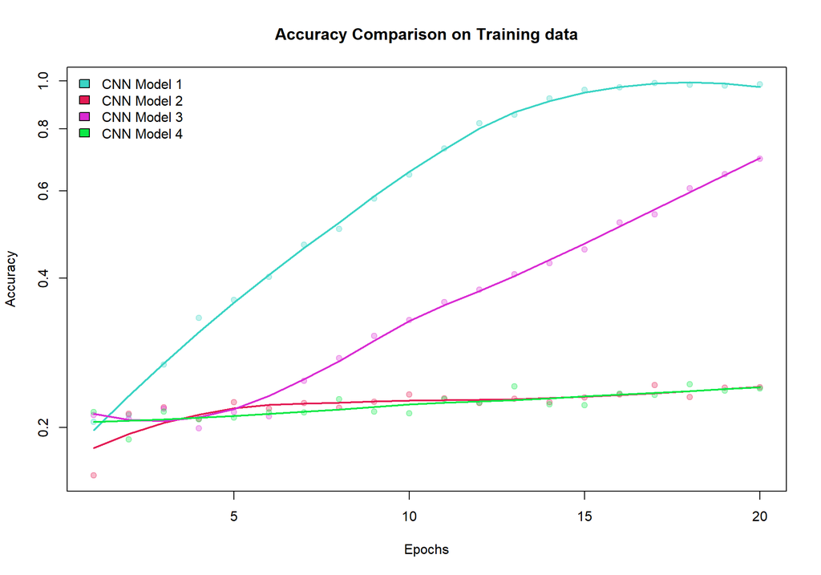

```r
  #Plots for Accuracy on Training sets

  #Function to add a smooth line to points in plot
  smooth_line <- function(y) {
    x = 1:length(y)
    out = predict(loess(y ~ x))
    return(out)
  }

  #Colours for each line
  cols = c("#3bd4c4", "#e31b54", "#d92bd3", "#09e845")

  #Plot Accuracy of both the models
  out = cbind(fit_CNN_Model_1$metrics$accuracy,
              fit_CNN_Model_2$metrics$accuracy,
              fit_CNN_Model_3$metrics$accuracy,
              fit_CNN_Model_4$metrics$accuracy)

  #Check performance
  matplot(out, pch = 19, ylab = "Accuracy", xlab = "Epochs", col = adjustcolor(cols, 0.3), log = "y", main = "Accuracy Comparison on Training data")
  matlines(apply(out, 2, smooth_line), lty = 1, col = cols, lwd = 2)
  legend("topleft", legend = c("CNN Model 1", "CNN Model 2", "CNN Model 3", "CNN Model 4"), fill = cols, bty = "n")
```

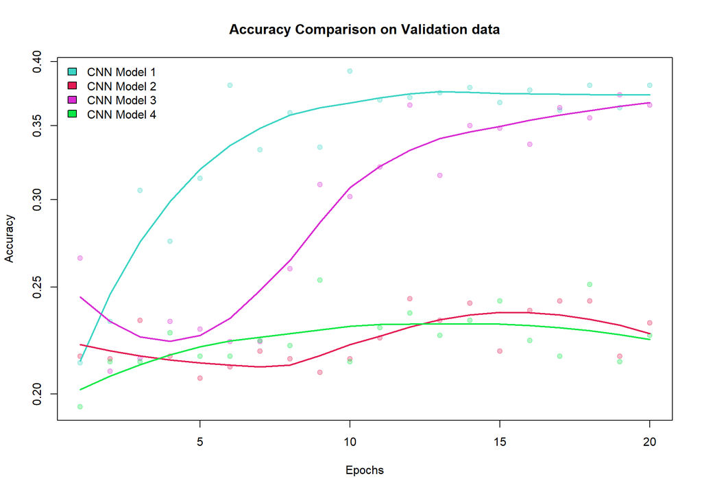

```r
  #Plots for Accuracy on Validation sets

  out = cbind(fit_CNN_Model_1$metrics$val_accuracy,
              fit_CNN_Model_2$metrics$val_accuracy,
              fit_CNN_Model_3$metrics$val_accuracy,
              fit_CNN_Model_4$metrics$val_accuracy)

  #Check performance
  matplot(out, pch = 19, ylab = "Accuracy", xlab = "Epochs", col = adjustcolor(cols, 0.3), log = "y", main = "Accuracy Comparison on Validation data")
  matlines(apply(out, 2, smooth_line), lty = 1, col = cols, lwd = 2)
  legend("topleft", legend = c("CNN Model 1", "CNN Model 2", "CNN Model 3", "CNN Model 4"), fill = cols, bty = "n")
```

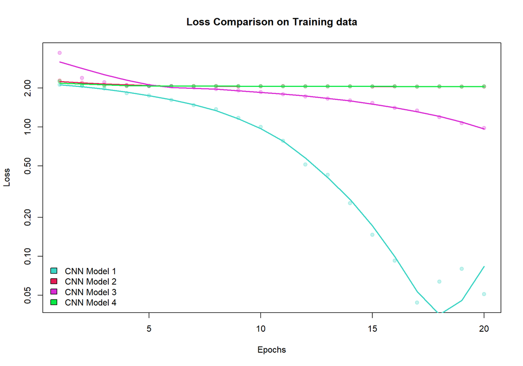

```r
  #Plots for Loss on Training sets

  #Plot Accuracy of both the models
  out = cbind(fit_CNN_Model_1$metrics$loss,
              fit_CNN_Model_2$metrics$loss,
              fit_CNN_Model_3$metrics$loss,
              fit_CNN_Model_4$metrics$loss)

  #Check performance
  matplot(out, pch = 19, ylab = "Loss", xlab = "Epochs", col = adjustcolor(cols, 0.3), log = "y", main = "Loss Comparison on Training data")
  matlines(apply(out, 2, smooth_line), lty = 1, col = cols, lwd = 2)
  legend("bottomleft", legend = c("CNN Model 1", "CNN Model 2", "CNN Model 3", "CNN Model 4"), fill = cols, bty = "n")
```

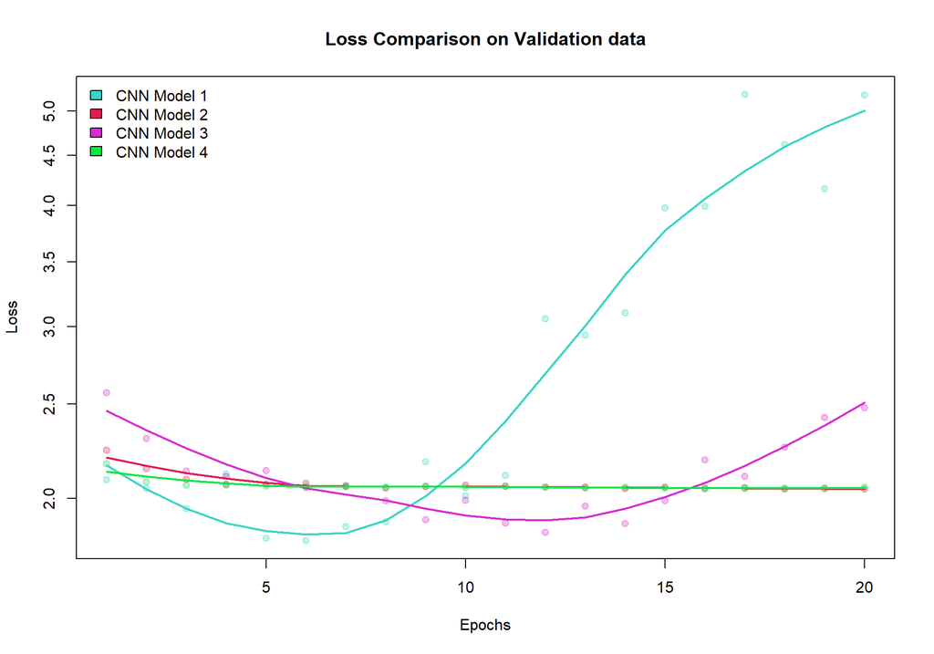

```r
  #Plots for Loss on Validation sets

  #Plot Accuracy of both the models
  out = cbind(fit_CNN_Model_1$metrics$val_loss,
              fit_CNN_Model_2$metrics$val_loss,
              fit_CNN_Model_3$metrics$val_loss,
              fit_CNN_Model_4$metrics$val_loss)

  #Check performance
  matplot(out, pch = 19, ylab = "Loss", xlab = "Epochs", col = adjustcolor(cols, 0.3), log = "y", main = "Loss Comparison on Validation data")
  matlines(apply(out, 2, smooth_line), lty = 1, col = cols, lwd = 2)
  legend("topleft", legend = c("CNN Model 1", "CNN Model 2", "CNN Model 3", "CNN Model 4"), fill = cols, bty = "n")
```

We will now evaluate predictive performance on training data for each model and check for the best fit.

```r
  class_labels = c("bathroom", "bedroom", "children_room", "closet", "corridor", "dinning_room",
                    "garage", "kitchen", "living_room", "stairs")

  #Model 1 Predict Training
  class_y = class_labels[max.col(y_train)]
  class_train_hat_1 = class_labels[CNN_Model_1 %>% predict(train_generator) %>% max.col()]
  tab_1 = table(class_y, class_train_hat_1)
  #Compute class sensitivity
  print(rbind(cbind(tab_1, cl_acc = diag(tab_1)/rowSums(tab_1))))
```

```
##               bathroom bedroom children_room closet corridor dinning_room
## bathroom             7      28             0      3        5            6
## bedroom             22      57            13      9       37           26
## children_room        1      15             1      0        8            4
## closet               2      10             3      1        8            8
## corridor            10      26             4      8       21           12
## dinning_room         7      28             3      3       12           11
## garage               2      14             3      2        9            5
## kitchen             24      76            12     22       36           26
## living_room         18      65            14     14       33           33
## stairs               3      12             3      4        4            8
##               garage kitchen living_room stairs     cl_acc
## bathroom           4      27          17      1 0.07142857
## bedroom            5      72          69     21 0.17220544
## children_room      3      14          10      0 0.01785714
## closet             1      15          16      4 0.01470588
## corridor           7      38          42      5 0.12138728
## dinning_room      10      28          29      6 0.08029197
## garage             1       3          11      2 0.01923077
## kitchen            7      69          77     18 0.18801090
## living_room       13      78          68     17 0.19263456
## stairs             1      21          19      3 0.03846154
```

```r
  #Model 2 Predict Training
  class_y_aug = class_labels[max.col(y_train_aug)]
  class_train_hat_2 = class_labels[CNN_Model_2 %>% predict(train_generator_aug) %>% max.col()]
  tab_2 = table(class_y_aug, class_train_hat_2)
  print(rbind(cbind(tab_2, cl_acc = diag(tab_2)/rowSums(tab_2))))
```

```
##               kitchen living_room     cl_acc
## bathroom           12          86 0.12244898
## bedroom            54         277 0.83685801
## children_room       7          49 0.21428571
## closet             10          58 4.07352941
## corridor           30         143 0.06936416
## dinning_room       24         113 2.02189781
## garage              4          48 0.23076923
## kitchen            61         306 0.75476839
## living_room        53         300 0.03399433
## stairs              8          70 3.55128205
```

```r
  #Model 3 Predict Training
  class_train_hat_3 = class_labels[CNN_Model_3 %>% predict(train_generator) %>% max.col()]
  tab_3 = table(class_y, class_train_hat_3)
  print(rbind(cbind(tab_3, cl_acc = diag(tab_3)/rowSums(tab_3))))
```

```
##               bathroom bedroom children_room closet corridor dinning_room
## bathroom             2      20             1      6        6           12
## bedroom             10      65             4     15       34           28
## children_room        2      10             1      4        4            8
## closet               6      15             0      7       10            2
## corridor             9      44             1      7       14           21
## dinning_room         2      28             2      3       13            9
## garage               2      18             2      4        7            3
## kitchen             16      60             6     27       31           44
## living_room          5      76             6     20       42           36
## stairs               3      18             0      4        5            4
##               garage kitchen living_room stairs     cl_acc
## bathroom           4      20          22      5 0.02040816
## bedroom           12      74          82      7 0.19637462
## children_room      1      12          11      3 0.01785714
## closet             2      12          10      4 0.10294118
## corridor           4      28          40      5 0.08092486
## dinning_room       6      33          35      6 0.06569343
## garage             1       6           9      0 0.01923077
## kitchen           14      67          88     14 0.18256131
## living_room        7      74          71     16 0.20113314
## stairs             2      15          23      4 0.05128205
```

```r
  #Model 4 Predict Training
  class_train_hat_4 = class_labels[CNN_Model_4 %>% predict(train_generator_aug) %>% max.col()]
  tab_4 = table(class_y_aug, class_train_hat_4)
  print(rbind(cbind(tab_4, cl_acc = diag(tab_4)/rowSums(tab_4))))
```

```
##               bedroom kitchen living_room     cl_acc
## bathroom            1      19          78 0.01020408
## bedroom             2      56         273 0.16918429
## children_room       0      14          42 0.75000000
## closet              0      12          56 0.01470588
## corridor            0      30         143 0.32369942
## dinning_room        0      14         123 0.30656934
## garage              0      10          42 0.01923077
## kitchen             4      67         296 0.15258856
## living_room         5      60         288 0.11898017
## stairs              1      13          64 0.01282051
```

From the above classification table, we can say that the model 2 and 4 are the worst model for image classification since they were able to classify images into only 2-3 classes. The overall accuracy of the models is very low as compared to the model 1 and 3. Also based on the graphs, the training and validation accuracy of the models are both very low indicating that the models are not able to capture the underlying patterns in the data. Also the training and validation loss is high (i.e. around 2 which is very far from zero), indicating that the model is not able to fit the data well. Hence we can say that the model 2 and 4 are underfitting.

Model 1 and 3 are able to classify images into respective classes with better precision than the model 2 and 4. Although both the models have high training accuracy but have low validation accuracy indicating that the models are not able to generalize well to new data. Also training loss is low but the validation loss is high, indicating that the models are complex. We can say that model 1 and 3 are overfitting.

But for our analysis, we will choose model 3 as the best model out of the above models since it is still able to classify images despite of overfitting.

## Performance Evaluation on Test Data

Now we will evaluate predictive performance for model 3 on testing data.

```r
  #Evaluate accuracy of test set of model 3
  AL = CNN_Model_3 %>% evaluate(test_generator, y_test, verbose = 0)
  print(paste0("Accuracy of Model 3 on Test data is ", AL[2]*100))
```

```
## [1] "Accuracy of Model 3 on Test data is 36.4277333021164"
```

```r
  print(paste0("Loss of Model 3 on Test data is ", AL[1]))
```

```
## [1] "Loss of Model 3 on Test data is 2.49576020240784"
```

```r
  #Model 3 Predict Test and display classification table
  class_ty = class_labels[max.col(y_test)]
  class_test_hat = class_labels[CNN_Model_3 %>% predict(test_generator) %>% max.col()]
  tab = table(class_ty, class_test_hat)
  print(rbind(cbind(tab, cl_acc = diag(tab)/rowSums(tab))))
```

```
##               bathroom bedroom children_room closet corridor dinning_room
## bathroom             2       7             1      2        2            3
## bedroom              4      30             2     10       11           19
## children_room        0       5             2      3        1            3
## closet               0       6             1      1        1            1
## corridor             3      13             1      1       11           15
## dinning_room         1      10             4      1        8            7
## garage               2       4             0      1        2            2
## kitchen              2      26             3     13       15           22
## living_room          2      30             2     14       13           27
## stairs               0       4             1      2        3            4
##               garage kitchen living_room stairs     cl_acc
## bathroom           4      12          15      1 0.04081633
## bedroom            9      31          43      6 0.18181818
## children_room      3       6           5      0 0.07142857
## closet             2       5          15      1 0.03030303
## corridor           7      10          22      3 0.12790698
## dinning_room       3      15          18      1 0.10294118
## garage             1       4           8      1 0.04000000
## kitchen           11      31          58      2 0.16939891
## living_room       10      30          43      5 0.24431818
## stairs             0      10          14      0 0.00000000
```